# Aprendizado de Máquina I

### Gabriel Sanfins

#### `gabrielsanfins@id.uff.br`

### 05 - Métodos não-paramétricos: Árvores de regressão

# Árvores de regressão

## Visão geral

- Resultados muito interpretáveis
- Particionamento recursivo do espaço das covariáveis
- Imita, muito vagamente, processos cognitivos de tomadas de decisão
- Lidam bem com covariáveis qualitativas e quantitativas
- Poder preditivo usualmente menor que o de outros métodos
- Usualmente são *não robustas*: uma pequena mudança nos dados pode levar a estimativas muito discrepantes
  - Tentaremos contornar esses problemas

## Um exemplo

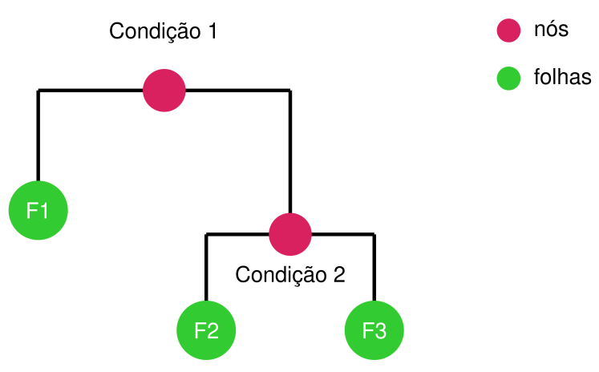

Figura 4.6 de [AME]

## Um exemplo mais concreto

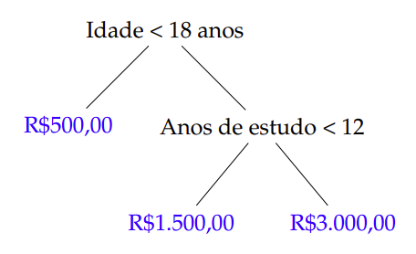

Figura 4.7 de [AME]: Regressão do salário de um indivíduo dadas as covariáveis idade e anos de estudo.

## Formalizando

- Partição do espaço das covariáveis
  - Regiões $R_1, \dots, R_j$ distintas disjuntas
  - A predição para a resposta $Y$ de uma observação $\mathbf{x}$ que está na região $k$ é a média das respostas cujos respectivos $\mathbf{x}$ também estão nessa região:
    $$g(\mathbf{x}) = \frac{1}{\#\{i ~ | ~ \mathbf{x}_i \in R_k\}} \sum_{i ~ | ~ \mathbf{x}_i \in R_k} y_i.$$

## Formalizando

- Criação em duas etapas:
  1. Criação de uma árvore “completa” e “complexa”
     - Árvores **puras**
     - Partições onde os valores de $Y$ no conjunto de treinamento em cada folha sejam “homogêneos”
  2. Poda da árvore para evitar sobreajuste
     - Reduzir a complexidade da árvore
     - Remover nós “desnecessários”

## Etapa 1: Criação da árvore

- Medida de plausibilidade de uma árvore $T$: **erro quadrático médio**:
  $$\mathcal{P}(T) = \frac{1}{n} \sum_R \sum_{i ~ | ~ \mathbf{x}_i \in R} (y_i - \widehat{y}_R)^2$$
- $\widehat{y}_R$: valor predito para a resposta de uma observação em $R$
- $\displaystyle \mathrm{arg}\min_T \mathcal{P}(T)$ $\Rightarrow$ estudar **todas** as partições! Inviável
- Heurística simplificadora: *divisão binária recursiva*

## Etapa 1: Criação da árvore

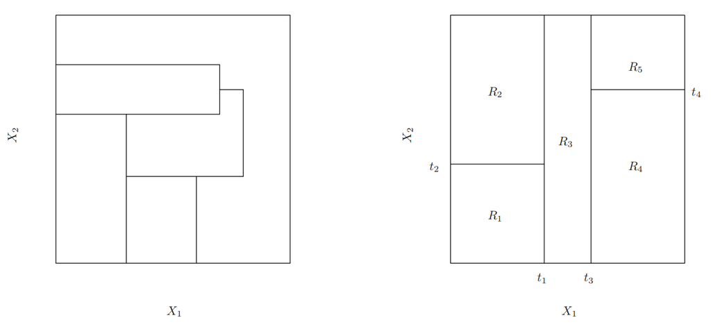

Figura 8.3 de [ISLP]: Particionamento proveniente de *divisão binária recursiva* (direita) e particionamento mais geral (esquerda)

## Etapa 1: Criação da árvore

- Particionar o espaço de covariáveis em duas regiões
  - Busca de covariável $x_i$ e corte $t_1$
  - Partição $(R_1, R_2)$ com predições de menor EQM:
    $$\sum_{i ~ | ~ \mathbf{x}_i \in R_1} (y_i - \widehat{y}_{R_1})^2 + \sum_{i ~ | ~ \mathbf{x}_i \in R_2} (y_i - \widehat{y}_{R_2})^2$$
  - $R_1 = \{\mathbf{x} ~ | ~ x_i < t_1\}$ e $R_2 = \{\mathbf{x} ~ | ~ x_i \geq t_1\}$

## Etapa 1: Criação da árvore

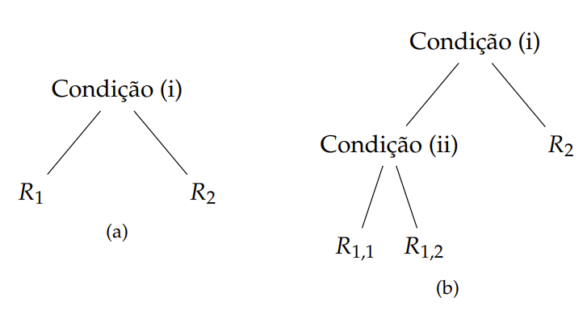

Figura 4.8 de [AME]: a) Onde chegamos com o passo-a-passo anterior; b) onde queremos chegar no próximo passo

- Nó inicial fixado
- Particionar $R_1$ ou $R_2$ em regiões menores
- Repetir a estratégia

## Etapa 1: Criação da árvore

- Particionar $R_1$ ou $R_2$ em regiões menores
  - Busca de covariável $x_j$ e corte $t_2$
  - Decidir qual região particionar, $R_1$ ou $R_2$
  - Sempre para minimizar o EQM
- Assumindo escolhida a região $R_1$, temos:
  $$R_{1,1} = \{\mathbf{x} ~ | ~ x_i < t_1, x_j < t_2\}$$
  $$R_{1,2} = \{\mathbf{x} ~ | ~ x_i < t_1, x_j \geq t_2\}$$
  $$R_2 = \{\mathbf{x} ~ | ~ x_i \geq t_1\}$$

## Etapa 1: Criação da árvore

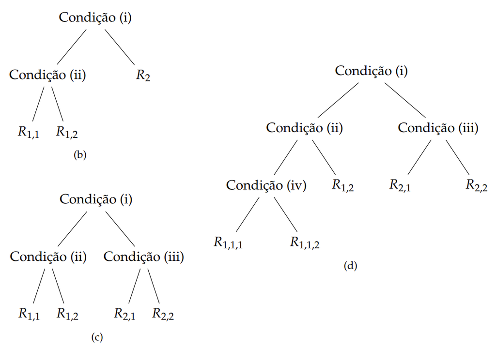

Figura 4.8 de [AME]: b) Onde chegamos com o passo-a-passo anterior; c) d) continuações hipotéticas do processo

- Continuar até cada folha ter “poucas” observações

## Etapa 1: Criação da árvore

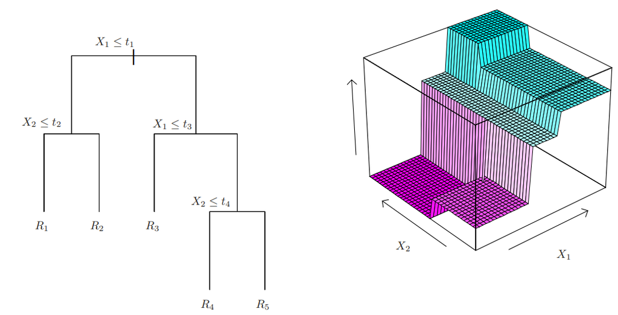

Figura 8.3 de [ISLP]: Árvore (esquerda) e gráfico da função $g$ correspondente (direita)

## Um exemplo até aqui

$X \sim \mathcal{U}[0, 4]$

$f(x) = \sin(\pi x)$

$Y = f(X) + \varepsilon$

$\varepsilon \sim \mathcal{N}(0, 0.4)$

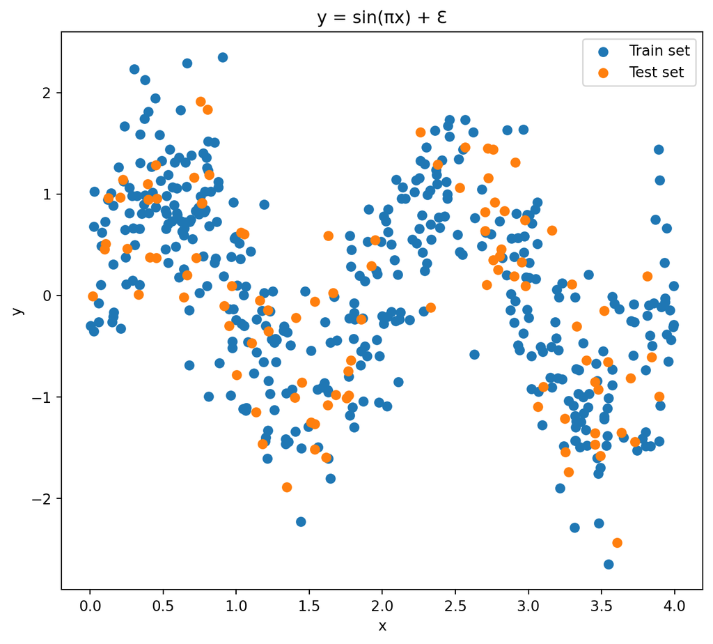

## Um exemplo até aqui

scikit-learn - [DecisionTreeRegressor](https://scikit-learn.org/stable/modules/generated/sklearn.tree.DecisionTreeRegressor.html)

```python
DTR = DecisionTreeRegressor(max_depth = None, min_samples_leaf = 5)
DTR.fit(x_tr.reshape(-1, 1), y_tr)
print('ATENÇÃO: Diversos hiperparâmetros para ajustar!')
```

```
ATENÇÃO: Diversos hiperparâmetros para ajustar!
```

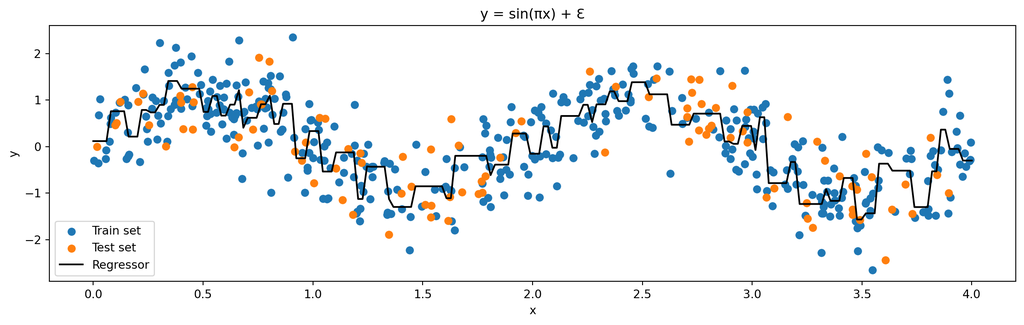

## Um exemplo até aqui

Visualizando (ou tentando visualizar…) a árvore

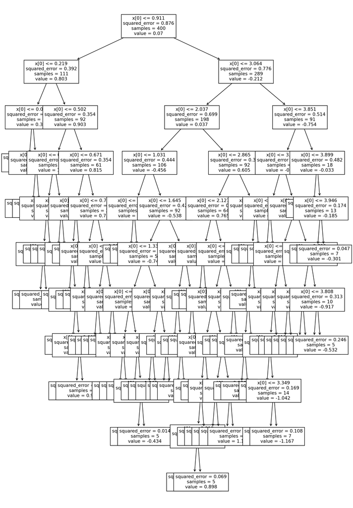

```python
plt.figure(figsize=(12,20))
plot_tree(DTR, fontsize=10)
plt.show()
```

## Etapa 2: Poda da árvore

- Retirar nós da árvore para melhorar sua capacidade preditiva
  - Como escolher os nós a serem removidos?
- *Poda por custo de complexidade*
  - Ideia reminiscente do Lasso
  - Árvore “grande” $T$ e hiperparâmetro $\alpha$
  - Sub-árvore $T_{\alpha} \subset T$ que minimiza
    $$\sum_{m = 1}^{|T_{\alpha}|} \sum_{i ~ | ~ \mathbf{x}_i \in R_m} (y_i - \widehat{y}_{R_m})^2 + \alpha |T_{\alpha}|$$

## Etapa 2: Poda da árvore

- Sub-árvore $T_{\alpha} \subset T$ que minimiza
  $$\sum_{m = 1}^{|T_{\alpha}|} \sum_{i ~ | ~ \mathbf{x}_i \in R_m} (y_i - \widehat{y}_{R_m})^2 + \alpha |T_{\alpha}|$$
  - $|T_{\alpha}|$: número de nós terminais da árvore
  - $R_m$: região correspondente ao $m$-ésimo nó terminal
- $\alpha$ controla equilíbrio entre **complexidade** e **ajuste aos dados** (encontrado por validação cruzada)
- Poda diminui variância mas aumenta o viés

## Continuando no exemplo

```python
DTR = DecisionTreeRegressor(max_depth = None, min_samples_leaf = 5,
                            ccp_alpha = 0.01)
DTR.fit(x_tr.reshape(-1, 1), y_tr);
```

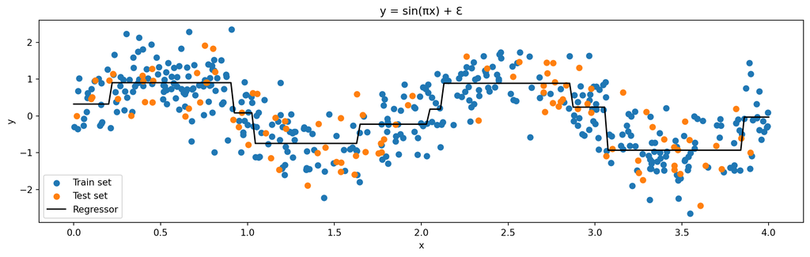

## Visualizando a árvore

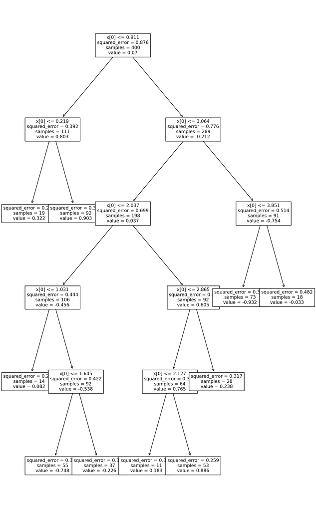

```python
plt.figure(figsize=(12,20))
plot_tree(DTR, fontsize=10)
plt.show()
```

## Escolhendo $\alpha$ por validação cruzada

```python
DTR = DecisionTreeRegressor(max_depth = None, min_samples_leaf = 5)
param_grid_DTR = {"ccp_alpha": [0.0001, 0.0001, 0.001, 0.01, 0.03, 0.05, 0.07, 0.1, 0.2]}
DTRCV = GridSearchCV(DTR, param_grid = param_grid_DTR, scoring='neg_mean_squared_error', cv = 5)

DTRCV.fit(x_tr.reshape(-1, 1), y_tr)
print(DTRCV.best_estimator_)
```

```
DecisionTreeRegressor(ccp_alpha=0.01, min_samples_leaf=5)
```

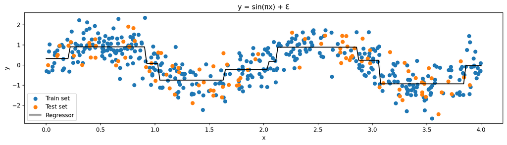

## Visualizando a árvore podada

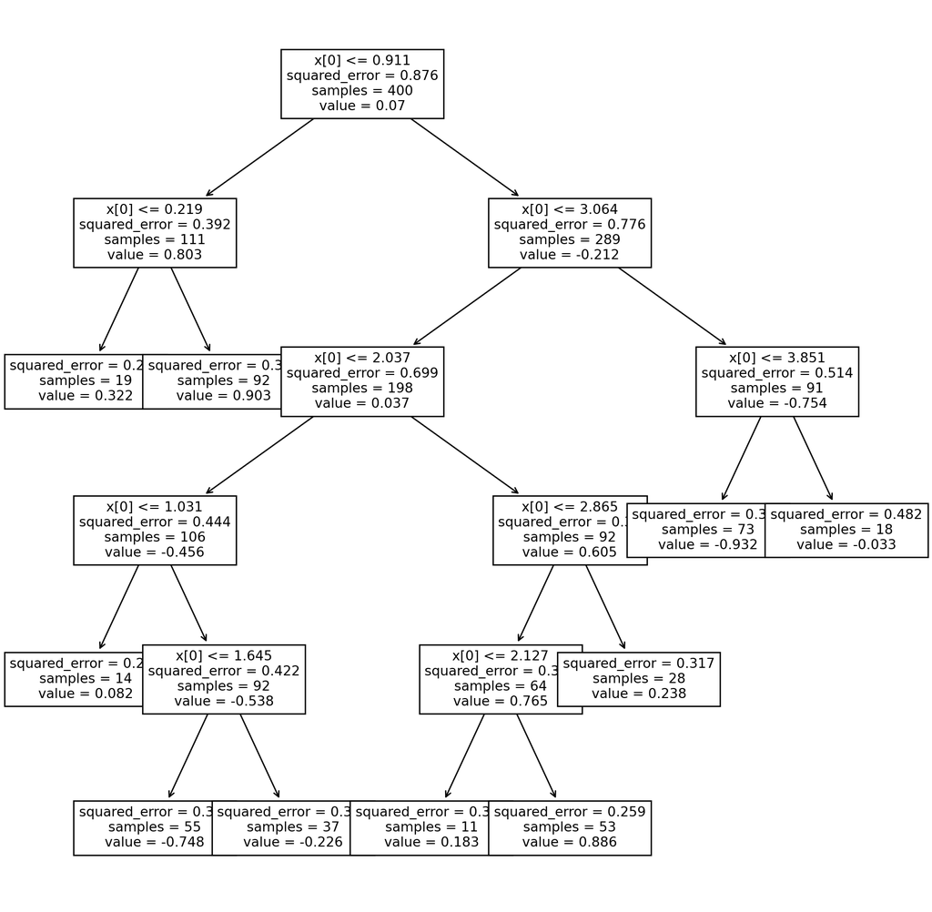

## Árvores *vs.* modelos lineares

- Modelos lineares: $\displaystyle g(\mathbf{x}) = \beta_0 + \sum_{i = 1}^{p} \beta_i x_i$
- Árvores: $\displaystyle g(\mathbf{x}) = \sum_{m = 1}^{M} c_m \mathbb{I}_{R_m}(\mathbf{x})$
  - $\mathbb{I}_A$ função indicadora do conjunto $A$
  - $R_1, \dots, R_M$ partição do espaço de covariáveis
  - Mais adequada para capturar relações não-lineares entre as covariáveis e a resposta

# *Bagging* e Florestas Aleatórias

## Uma floresta aleatória… 🙂

[figure not shown]

## Visão de ambos os métodos

- Agregar $B$ árvores para melhorar o poder preditivo
- *Bagging*
  - Gerar árvores através de *amostras bootstrap* dos dados
  - Funciona para outros modelos, não somente árvores
- Florestas aleatórias
  - Gerar árvores através de *amostras bootstrap* dos dados
  - Crescer a árvore com **menos opções**: em cada nó, só $m < p$ covariáveis sorteadas

## *Bagging*

- Contexto de regressão, duas funções de predição: $g_1$ e $g_2$
  - Riscos condicionados em $\mathbf{x}$ mas não na amostra de treinamento $\Rightarrow$ $\mathbb{E} = \mathbb{E}_{\mathcal{D}, Y}$
    $$\mathbb{E}\left[ \left. \left(Y - g_1(\mathbf{x})\right)^2 \right| \mathbf{x} \right] \quad \text{e} \quad \mathbb{E}\left[ \left. \left(Y - g_2(\mathbf{x})\right)^2 \right| \mathbf{x} \right]$$
  - Estimador combinado $\displaystyle g(\mathbf{x}) = \frac{g_1(\mathbf{x}) + g_2(\mathbf{x})}{2}$
  - Sob certas hipóteses: $\displaystyle \mathbb{E}\left[ \left. \left(Y - g(\mathbf{x})\right)^2 \right| \mathbf{x} \right] \leq \mathbb{E}\left[ \left. \left(Y - g_i(\mathbf{x})\right)^2 \right| \mathbf{x} \right], i = 1, 2$

## *Bagging*

- Generalizar para $B$ funções de predição:
  $$g(\mathbf{x}) = \frac{1}{B} \sum_{b = 1}^{B} g_b(\mathbf{x})$$
  - $g_b$ geradas através de *amostras bootstrap*
    - $\mathbf{x}_1, \dots, \mathbf{x}_n$ conjunto de treinamento
    - $\mathbf{x}_{i_1}, \dots, \mathbf{x}_{i_n}$ amostras **com reposição** do conjunto de treinamento $\Rightarrow$ **amostra bootstrap**
    - Usar esse conjunto para estimar $g_b$

## *Bagging* - atenção!

- As $g_b$ precisam ser **não-viesadas** $\Rightarrow$ **não** podar as árvores!
- As $g_b$ precisam ser descorrelacionadas $\Rightarrow$ isso é um problema, na verdade…
  - Florestas aleatórias tentam resolvê-lo
  - Mas vejamos uma coisa de cada vez!

## Um exemplo

scikit-learn - [BaggingRegressor](https://scikit-learn.org/stable/modules/generated/sklearn.ensemble.BaggingRegressor.html)

```python
DTB = BaggingRegressor(estimator = DecisionTreeRegressor(max_depth = None, min_samples_leaf = 5), n_estimators = 1000)
print('ATENÇÃO: Diversos hiperparâmetros para ficar atento/a!')
```

```
ATENÇÃO: Diversos hiperparâmetros para ficar atento/a!
```

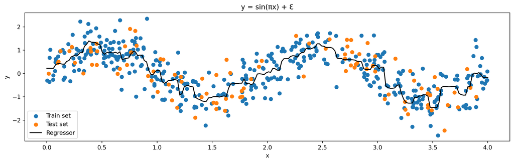

## Fechando o *bagging*

- Menos interpretável que árvores de regressão
- Potencialmente maior poder preditivo

## Florestas aleatórias

- Bagging
  - $g_b$ construídos a partir de amostras bootstrap
  - Estimadores correlacionados!
- Florestas aleatórias visam diminuir essa correlação
  - Criar um novo nó da árvore
  - Escolher **não mais** uma dentre as $p$ covariáveis
  - Escolher uma dentre $m < p$
  - $m$ candidatas escolhidas aleatoriamente
  - $m \approx p/3$ ou $\sqrt{p}$ leva a bons resultados

## Um exemplo

scikit-learn - [RandomForestRegressor](https://scikit-learn.org/stable/modules/generated/sklearn.ensemble.RandomForestRegressor.html)

```python
RF = RandomForestRegressor(n_estimators = 1000, max_depth = None, min_samples_leaf = 5, max_features = 'log2')
print('ATENÇÃO: Diversos hiperparâmetros para ficar atento/a!')
print('SÓ TEMOS UM ATRIBUTO!!!! É equivalente ao bagging.')
```

```
ATENÇÃO: Diversos hiperparâmetros para ficar atento/a!
SÓ TEMOS UM ATRIBUTO!!!! É equivalente ao bagging.
```

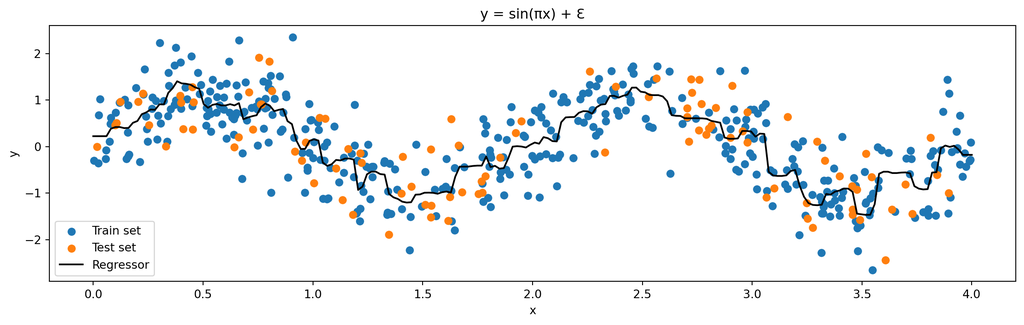